# DA_project

#### 4.6 DBSCAN:

*Overview:*

- DBSCAN stands for Density-Based Spatial Clustering for Applications with Noise. It’s a method used to identify outliers and cluster observations based on their density.
- DBSCAN requires two main parameters: epsilon (eps) and minimum points (MinPts). MinPts should be chosen based on the size of the dataset, with a minimum value of 3. We’ll experiment with different MinPts values to observe their impact on clustering.
- Determining Epsilon (eps): Epsilon can be determined using the K-nearest neighbor (KNN) method. We’ll compute the KNN distance plot for each MinPts value to find the optimal epsilon. The “knee” of the plot indicates the point where a sharp change occurs, helping us identify the optimal epsilon.
- We’ll try MinPts values ranging from 3 to 8 and compute the KNN distance plot for each. This will allow us to find the best epsilon value for each MinPts parameter.

```r
# Define the range of MinPts values
min_pts_values <- 3:8

# Initialize lists to store optimal eps values and DBSCAN results
optimal_eps <- c(1.7, 1.8, 2, 2, 2.2, 2.2)
dbscan_results <- list()

# Set up the plotting layout
par(mfrow = c(3, 2))
```

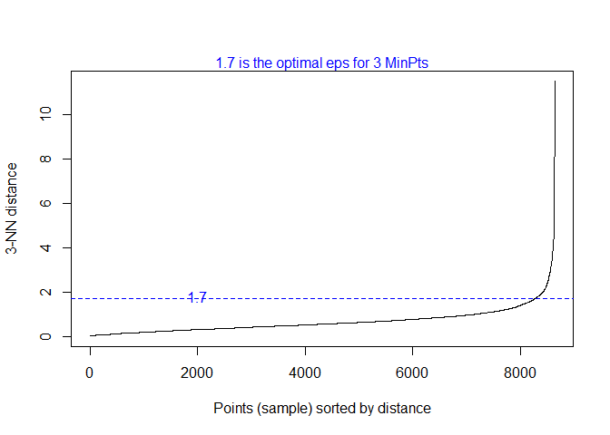

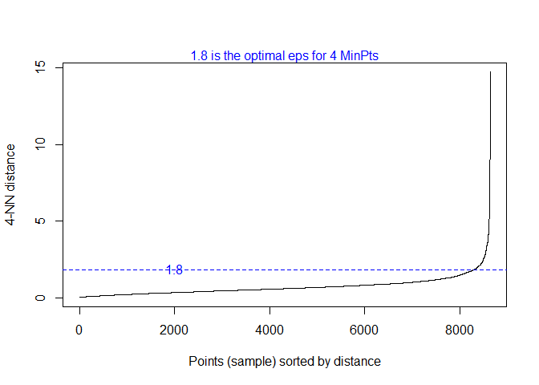

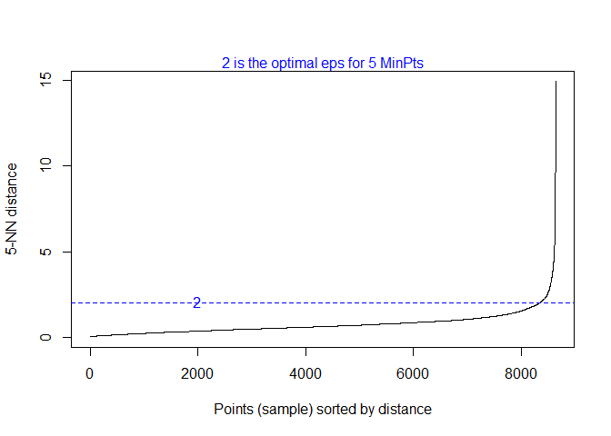

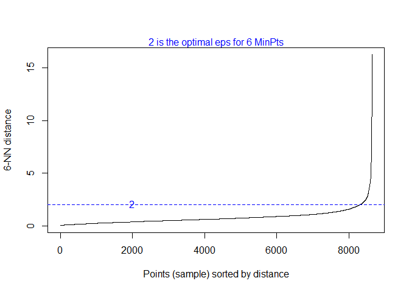

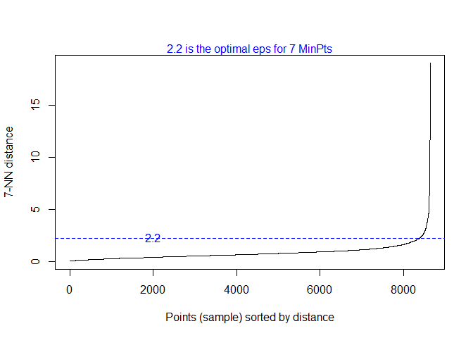

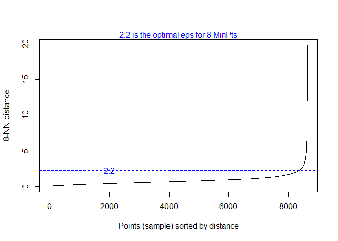

```r
# Iterate through different values of MinPts
for (i in seq_along(min_pts_values)) {
  # Compute the kNN distance plot for the current MinPts value
  kNN_plot <- dbscan::kNNdistplot(cc.scale, k = min_pts_values[i])

  # Add a horizontal line to indicate the optimal eps
  abline(h = optimal_eps[i], lty = 2, col = "blue")

  # Add text to indicate the optimal eps
  text(x = 2000, y = optimal_eps[i] + 0.1, labels = as.character(optimal_eps[i]), col = "blue")

  # Add a label
  mtext(paste(optimal_eps[i], "is the optimal eps for", min_pts_values[i], "MinPts"), col = "blue")

  # Compute DBSCAN algorithm for the current MinPts and eps combination
  dbscan_results[[i]] <- fpc::dbscan(cc.scale, eps = optimal_eps[i], MinPts = min_pts_values[i])
}
```